# Analysis of coverage in capture experiments

Merly Escalona merlyescalona@uvigo.es

# Introduction

In order to integrate a new feature of on/off target levels of coverage in NGSphy, I needed to understand coverage variation that one could find in a capture experiment. Goals are basically:

1. Understand the coverage variation within samples and loci to be able to model it for both NGSphy parameterization and furthers simulations.
2. Find out whether there is a correlation between the coverage and the phylogenetic distance to the reference species, used for the probe generation. Expecting that the closer the sample is to the reference the higher the coverage obtained is.

# Data

Data used comes from Rute’s Hummingbird project. Most of the information reported here about the samples and targets was extracted from the paper.

- **Samples**: species were chosen so that all the nine major Trochiliform clades reported by Bleiweiss et al. [1] and McGuire et al. [2] and many of the characteristic subclades illustrated by McGuire et al. [2] were represented.
  - 32 species - the National Museum of Natural History, Smithsonian Institution
  - 14 species - the Louisiana State University Museum of Natural Sciences
- **Target regions**: probes were selected from one-to-one orthologs between chicken (*Gallus gallus*) and zebra finch (*Taeniopygia guttata*) as annotated in ENSEMBL version 66 annotation resulting in a final set:
  - 166.322 probes
  - corresponding to 2950 genes
  - summing up to approximately 20 Mb (for an approximately 7 Mb of total captured sequence).
- The **datasets** I’m using `BAM` files corresponding to the mappings of the targeted-sequencing to 2 references.
  - 46 files, corresponding to the samples mapped to an ingroup *Calypte anna* (from now on called `map2Anna`).
  - 48 files (46 samples + Aan + Swift), corresponding to the samples an outgroup *Chaetura pelagica* (from now on called `map2Swift`).

## Processing and storage

Workspace `triploid` (UVigo):

- Original data from Dataset 1, is stored in: `triploid.uvigo.es`
- Under the user folder: `/home/merly/ research/cph-bam-coverage`

Workspace `randy` (KU):

- Original data from Dataset 1 and 2, is stored in: `randy.popgen.dk`
- Under the user folder:
  - `/home/merly/anna`
  - `/home/merly/swift`

# Targeted regions

Targeted regions are exons, retrieved a posteriori, due to the fact that the original probes for this project was lost during a flood.

- **`Ingroup reference`**: Original target files given was a GFF file: `Calypte_anna.gene.CDS.2750.gff` [1.6M]. This file was converted into a BED file, keeping only chromosome (scaffold), start and end position of the targets.
  1. Filtering regions with size 0
- **`Outgroup reference:`**: For this one, I received 2 files. One that had the relation one-to-one orthologs between the genes from Anna and the Swift (`48birds_ortholog.list.chi.anna.cpe.hum.finch` [656K]). The second, is a GFF file, which contains the exons from Swift (`Chaetura_pelagica.CDS.gff`[8.5M]). I had to get the targeted regions from the GFF files, taking into account that I needed the genes matching to Anna, and also I needed those genes that were actually used in the Anna’s targets (`Calypte_anna.gene.CDS.2750.gff`):
  1. Keep the gene that matched both Anna and Swift species within this file `48birds_ortholog.list.chi.anna.cpe.hum.finch`.
  2. Filter out those where there was no match (Gene in Anna == “-” or Gene in Swift == “-”)
  3. Filtering regions with size 0
  4. Check that all the targets in `Chaetura_pelagica.CDS.gff` where codon regions (`CDS`).
  5. Match the genes obtained in (4), to the data in `Calypte_anna.gene.CDS.2750.gff` so I’ll have the same covered genes.
  6. Match the resulting genes from (5) to `Chaetura_pelagica.CDS.gff` and keep those regions matching both Anna and Swift.

```r
WD="/media/merly/Baymax/research/cph-visit/coverage-analysis/files/"
birds48filename=paste0(WD,"48birds_ortholog.list.chi.anna.cpe.hum.finch")
swiftgff=paste0(WD,"Chaetura_pelagica.CDS.gff")
annagff=paste0(WD,"Calypte_anna.gene.CDS.2750.gff")
birds=read.table(birds48filename, header=T,
    colClasses=c("character","numeric","character","character",
      "character","character","character"))
swift=read.table(swiftgff,
    colClasses=c("character","character","character","numeric",
      "numeric","character","character","character","character"))
anna=read.table(annagff,
    colClasses=c("character","character","character","numeric",
      "numeric","character","character","character","character"))

birds.2=birds[birds$anna!="-",]
birds.3=birds.2[birds.2$swift!="-",]
birds.4=unique(birds.3)
birds.5=birds.4[,c("anna","swift")]
birds.5$swift=paste0("Parent=",birds.5$swift,";")
birds.5$anna=paste0("Parent=Aan_", birds.5$anna,";")
annaGenes=unique(anna$V9[birds.5$anna %in% anna$V9])
birds.6=birds.5[birds.5$anna %in% annaGenes, ]
swiftGenes=birds.6$swift

swift.2=swift[swift$V3=="CDS",]
swift.3=swift.2[swift.2$V9 %in% birds.6$swift,]
swift.3$size=swift.3$V5-swift.3$V4
swift.4=swift.3[swift.3$size>0,]
anna.2=anna[(anna$V5-anna$V4)>0,]
swift.4=swift.4[,1:(ncol(swift.4)-1)]
write.table(swift.4[,c(1,4,5)],
  file=paste0(WD,"targets.swift.2.bed"),
  row.names = F,col.names = F, quote = F, sep = "\t")
write.table(swift.4,
  file=paste0(WD,"Chaetura_pelagica.CDS.2.gff"),
  row.names = F,col.names = F, quote = F, sep = "\t")
write.table(anna.2[,c(1,4,5)],
  file=paste0(WD,"targets.anna.2.bed"),
  row.names = F,col.names = F, quote = F, sep = "\t")
write.table(anna.2,
  file=paste0(WD,"Calypte_anna.gene.CDS.2750.2.gff"),
  row.names = F,col.names = F, quote = F, sep = "\t")
write.table(birds.6,
  file=paste0(WD,"Calypte_anna.Chaetura_pelagica.ids"),
  row.names = F,col.names = F, quote = F, sep = "\t")
```

## Number of targeted regions per gene

## Number of targeted regions per scaffold

- Scaffolds: where genes are located.

## Targeted regions size distribution

# On-target coverage

I obtained the coverage of the targeted regions using **`bedtools`** (v. 2.22.0), module `coverage`. With this, and the option `-hist` I can report a histogram of coverage for each feature in A as well as a summary histogram for `_all_` features in A. Output (tab delimited) after each feature in A (from [`bedtools` documentation](http://bedtools.readthedocs.io/en/latest/content/tools/coverage.html)))

1. depth
2. `#` bases at depth
3. size of A
4. % of A at depth

```r
for bamfile in $(find $HOME/anna/originals -name "*.bam"); do
  tag=$(echo $(basename $bamfile) | tr "_" " " | awk '{print $1}')
  nohup /home/merly/src/bedtools2/bin/bedtools coverage -hist -abam $bamfile -b Chaetura_pelagica.CDS.2.gff | gzip > $HOME/anna/bedtools/cov/${tag}.cov.gz &
done
for bamfile in $(find $HOME/swift/originals -name "*.bam"); do
  tag=$(echo $(basename $bamfile) | tr "_" " " | awk '{print $1}')
  nohup /home/merly/src/bedtools2/bin/bedtools coverage -hist -abam $bamfile -b Calypte_anna.gene.CDS.2750.2.gff | gzip > $HOME/swift/bedtools/cov/${tag}.cov.gz &
done
```

And so, I filtered the output to keep the coverage per region and the summary histogram separated.

```r
# (i.e)
for tag in $(cat $HOME/anna/files/samples.txt  ); do
  nohup zcat  $HOME/anna/bedtools/cov/H09.cov.gz | grep -v ^all | gzip >  $HOME/anna/bedtools/nohist/H09.nohist.gz &
  nohup zcat  $HOME/anna/bedtools/cov/H09.cov.gz | grep  ^all | gzip  >    $HOME/anna/bedtools/hist/H09.hist.gz &
done
for tag in $(cat $HOME/swift/files/samples.txt | tail -n+2 | head -46 ); do
  nohup zcat  $HOME/swift/bedtools/cov/H09.cov.gz | grep -v ^all | gzip >  $HOME/swift/bedtools/nohist/H09.nohist.gz &
  nohup zcat  $HOME/swift/bedtools/cov/H09.cov.gz | grep  ^all | gzip  >    $HOME/swift/bedtools/hist/H09.hist.gz &
done
```

## Breadth vs. depth

With the information extracted from the `bedtools coverage -hist`, we can see the relation between the breadth of coverage obtained and the depth per sample.

Map2 - target

Coverage per target overview

**map2Anna**

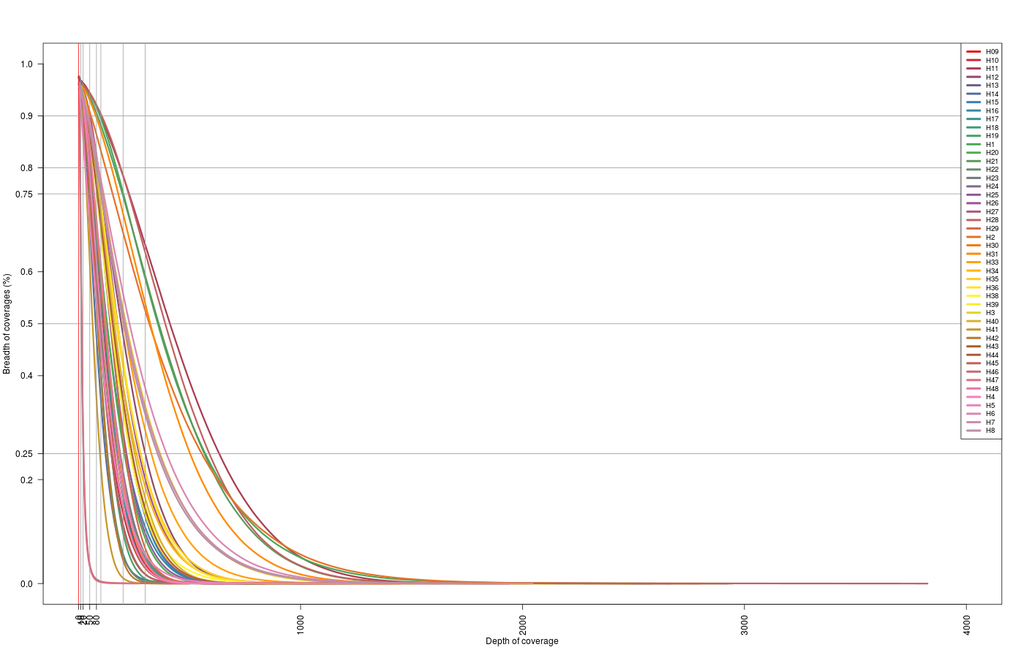

**map2Swift**

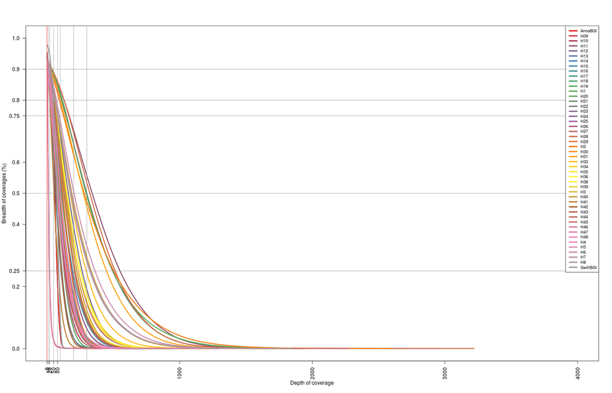

**Zoom**: 0x-100x.

**map2Anna**

**map2Swift**

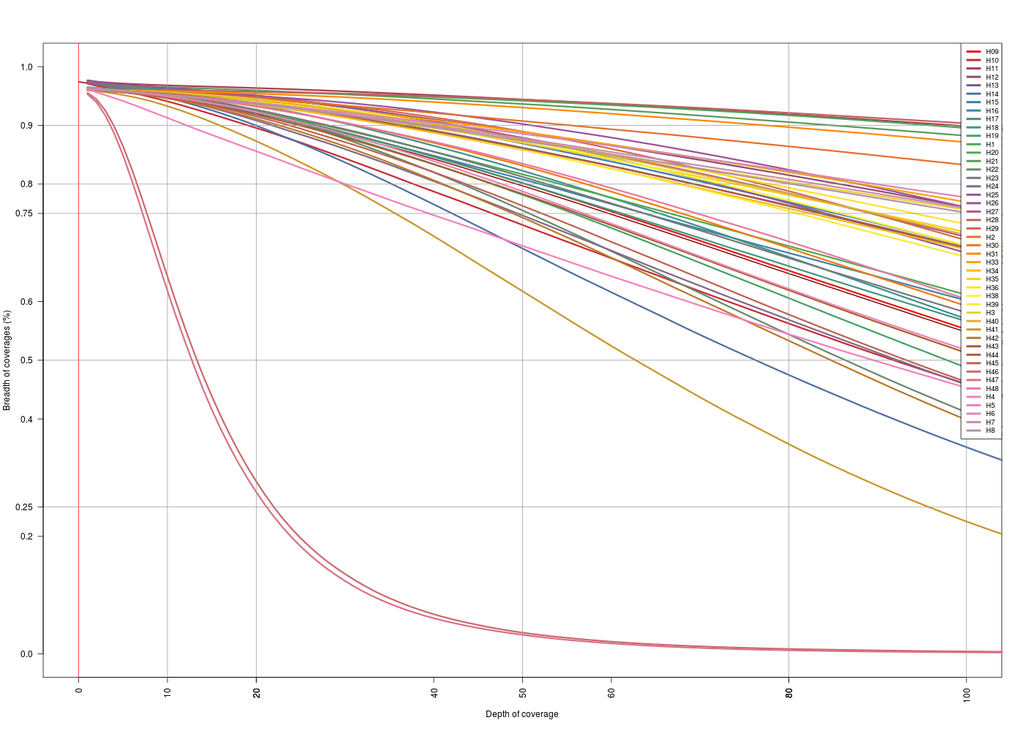

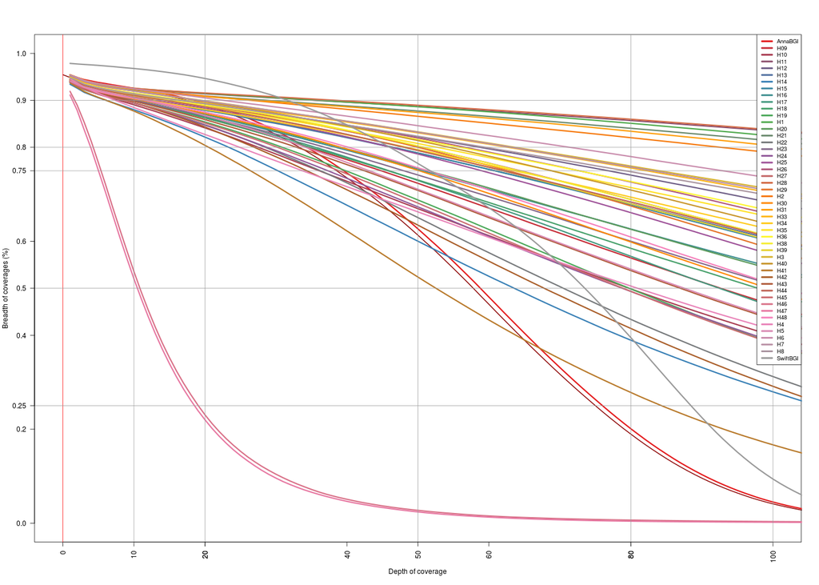

## Depth of coverage

From the `bedtools coverage` output I was able to extract the depth of coverage per target, gene and sample. I generated 2 matrices:

- Target depth: dimensions – number of targets $\times$ number of samples
- Gene depth: dimensions – number of genes $\times$ number of samples

Each cell of the matrix correspond to the sum of the number of times each base was covered within the target or the gene. Then, coverage was calculated as the mean value of all the depth of coverage of all the samples for a specific target/gene divided by the size of the corresponding target/gene.

For the depth of coverage for the samples, I summed the coverage of all targets and divided it by the total amount of bases that were targeted.

**Note:** Outliers presented below were calculated using the following:

```r
qnt <- quantile(data, probs=c(.25, .75))
H <- 1.5 * IQR(data)
y <- data
y[data < (qnt[1] - H)] <- "Outlier"
y[data > (qnt[2] + H)] <- "Outlier"
```

### Coverage per gene

- Why there are some genes with extremely high depth of coverage?
- Identify these outliers

```r
# Get the outliers
qnt <- quantile(coveragePerGeneAnna, probs=c(.25, .75))
H <- 1.5 * IQR(coveragePerGeneAnna)
y <- rep("black",length(coveragePerGeneAnna))
outliers=coveragePerGeneAnna
outliers[coveragePerGeneAnna < (qnt[1] - H)] <- -1
outliers[coveragePerGeneAnna > (qnt[2] + H)] <- -1
outliers[outliers>=0]=0
outliers[outliers<0]=1
numOutliers=sum(outliers)
sizeOutlier=coveragePerGeneAnna[coveragePerGeneAnna>4000]
outlier4KIndex=which(coveragePerGeneAnna>4000)
outlier4K=unique(anna.2$V9)[outlier4KIndex]
```

There is one gene with an extremely high coverage ( gene **Parent=Aan_R000349;** with coverage: **4,190.085**), and these are the targets of the selected gene:

```
cat files/Calypte_anna.gene.CDS.2750.2.gff | grep "Parent=Aan_R000349;" | awk '{ print $0,"\t", $5-$4}'

Scaffold3026    GeneWise    CDS 3   230 .   +   0   Parent=Aan_R000349;      227
```

```
samtools mpileup H1_map2Anna_merge_pair.clean0.sort.bam -r Scaffold3026:3-230
```

And the first 10 bp are shown up here, but most of the region look similar:

```
Scaffold3026    3       N       1408    TTTTTTTTTTTTTTTTTTTTTTTTTTTTTTTTTTTTTTTTTTTTTTTTTTTTTTTTTTTTTTTTTTTTTTTTTTTTTTTTTTT
Scaffold3026    4       N       1536    AAAAAAAAAAAAAAAAAAAAAAAAAAAAAAAAAAAAAAAAAAAAAAAAAAAAAAAAAAAAAAAAAAAAAAAAAAAAAAAAAAA
Scaffold3026    5       N       1690    TTTTTTTTTTTTTTTTTTTTTTTTTTTTTTTTTTTTTTTTTTTTTTTTTTTTTTTTTTTTTTTTTTTTTTTTTTTTTTTTTTT
Scaffold3026    6       N       1848    TTTTTTTTTTTTTTTTTTTTTTTTTTTTTTTTTTTTTTTTTTTTTTTTTTTTTTTTTTTTTTTTTTTTTTTTTTTTTTTTTTT
Scaffold3026    7       N       2110    TTTTTTTTTTTTTTTTTTTTTTTTTTTTTTTTTTTTTTTTTTTTCTTTTTTTTTTTTTTTTTTTTTTTTTTTTTTTTTTTTTT
Scaffold3026    8       N       2274    TTTTTTTTTTTTTTTTTTTTTTTTTTTTTTTTTTTTTTTTTTTTTTTTTTTTTTTTTTTTTTTTTTTTTTTTTTTTTTTTTTT
Scaffold3026    9       N       2413    AAAAAAAAAAAAAAAAAAAAAAAAAAAAAAAAAAAAAAAAAAAAAAAAAAAAAAAAAAAAAAAAAAAAAAAAAAAAAAAAAAA
Scaffold3026    10      N       2652    TTTTTTTTTTTTTTTTTTTTTTTTTTTTTTTTTTTTTTTTTTTTTTTTTTTTTTTTTTTTTTTTTTTTTTTTTTTTTTTTTTT
Scaffold3026    11      N       2874    GGGGGGGGGGGGGGGGGGGGGGGGGGGGGGGGGGGGGGGGGGGGGGGGGGGGGGGGGGGGGGGGGGGGGGGGGGGGGGGGGGG
Scaffold3026    12      N       3118    CCCCCCCCCCCCCCCCCCCCCCCCCCCCCCCCCCCCCCCCCCCCCCCCCCCCCCCCCCCCCCCCCCCCCCCCCCCCCCCCCCC
```

- An so, it is possible that this high coverage is also due to a repetitive element region.
- Why there are some genes with extremely high depth of coverage?
- Identify these outliers

```r
qnt <- quantile(coveragePerGeneSwift, probs=c(.25, .75))
H <- 1.5 * IQR(coveragePerGeneSwift)

outliersSwiftHigh=coveragePerGeneSwift
outliersSwiftHigh[coveragePerGeneSwift > (qnt[2] + H)] <- -1
outliersSwiftHigh[outliersSwiftHigh>=0]=0
outliersSwiftHigh[outliersSwiftHigh<0]=1
numOutliersHigh=sum(outliersSwiftHigh)
sizeOutlierHigh=coveragePerGeneSwift[coveragePerGeneSwift > (qnt[2] + H)]
outlierIndex=which(coveragePerGeneSwift > (qnt[2] + H))
outliersGenesSwiftHigh=unique(swift.4$V9)[outlierIndex]

outliersSwiftLow=coveragePerGeneSwift
outliersSwiftLow[coveragePerGeneSwift < (qnt[1] - H)] <- -1
outliersSwiftLow[outliersSwiftLow>=0]=0
outliersSwiftLow[outliersSwiftLow<0]=1
numOutliersLow=sum(outliersSwiftLow)
sizeOutlieLow=coveragePerGeneSwift[coveragePerGeneSwift < (qnt[1] - H)]
outlierIndex=which(coveragePerGeneSwift < (qnt[1] - H))
outliersGenesSwiftLow=unique(swift.4$V9)[outlierIndex]
```

I’m interested in those genes with coverage higher than the 3rd. quartile of the outliers with high coverage.

#### Gene size vs. depth of coverage

I’m looking for a relation between gene size and depth of coverage. So I fit a linear model to the data.

### Coverage per target

- There are some targets with extremely high depth of coverage. Reasons?
- Identify these outliers

#### Coverage distribution per target

## Overview

While there is no specific color key for the coverage values, this will only serve as an overview of the coverage per target/gene per sample.

- Yellow maximum coverage
- Red minimum coverage.
- Genes (Reduced matrix)
- Genes (Complete Matrix)
- Targets (Reduced Matrix)
- Targets (Complete matrix)
- 100 Genes for each dataset

`map2Anna`

`map2Swift`

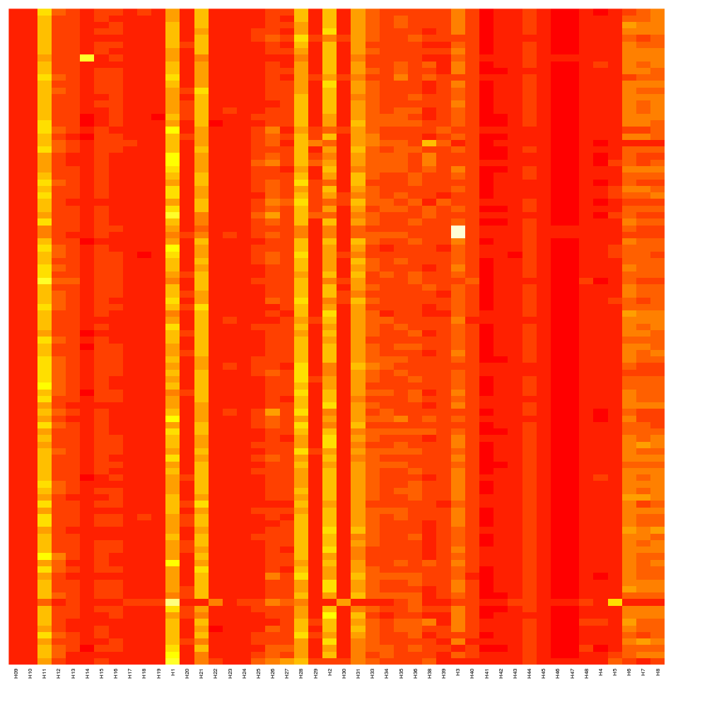

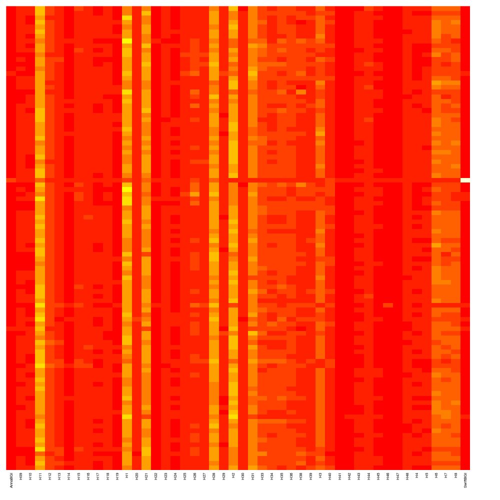

`map2Anna`

`map2Swift`

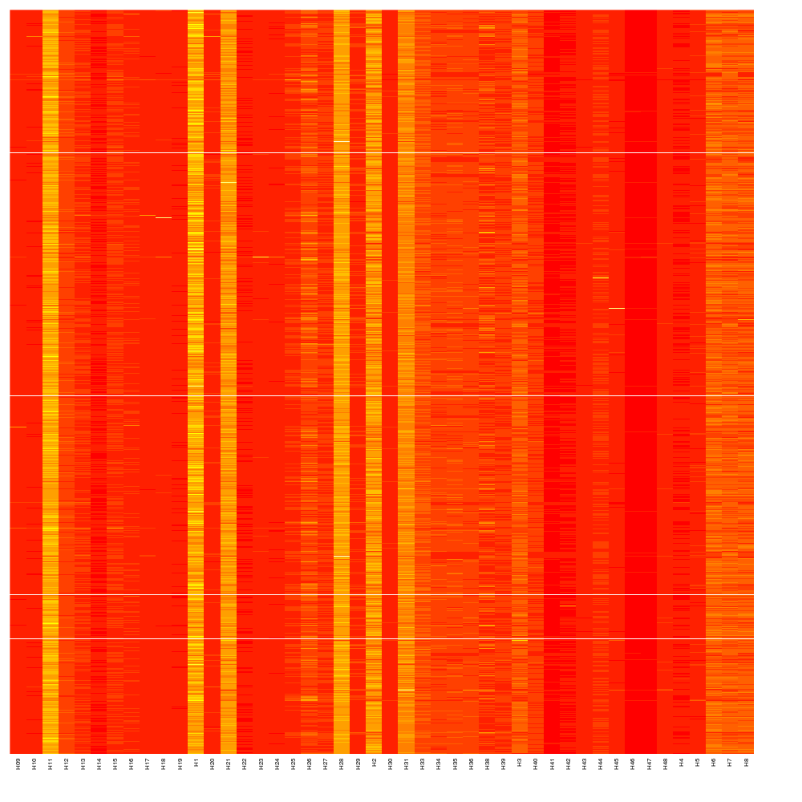

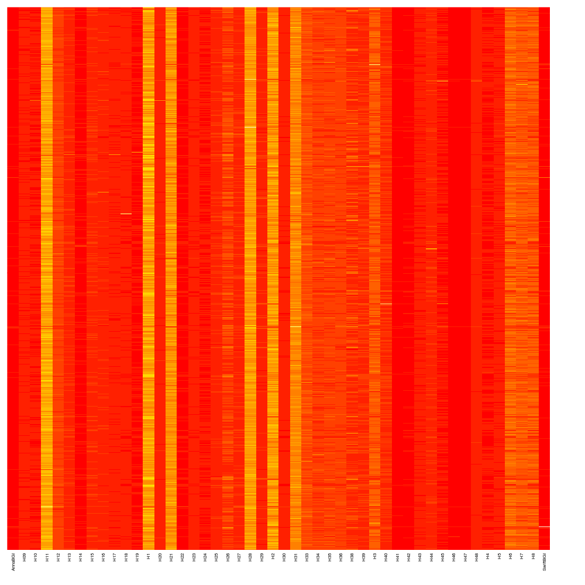

- 100 target regions for each dataset

`map2Anna`

`map2Swift`

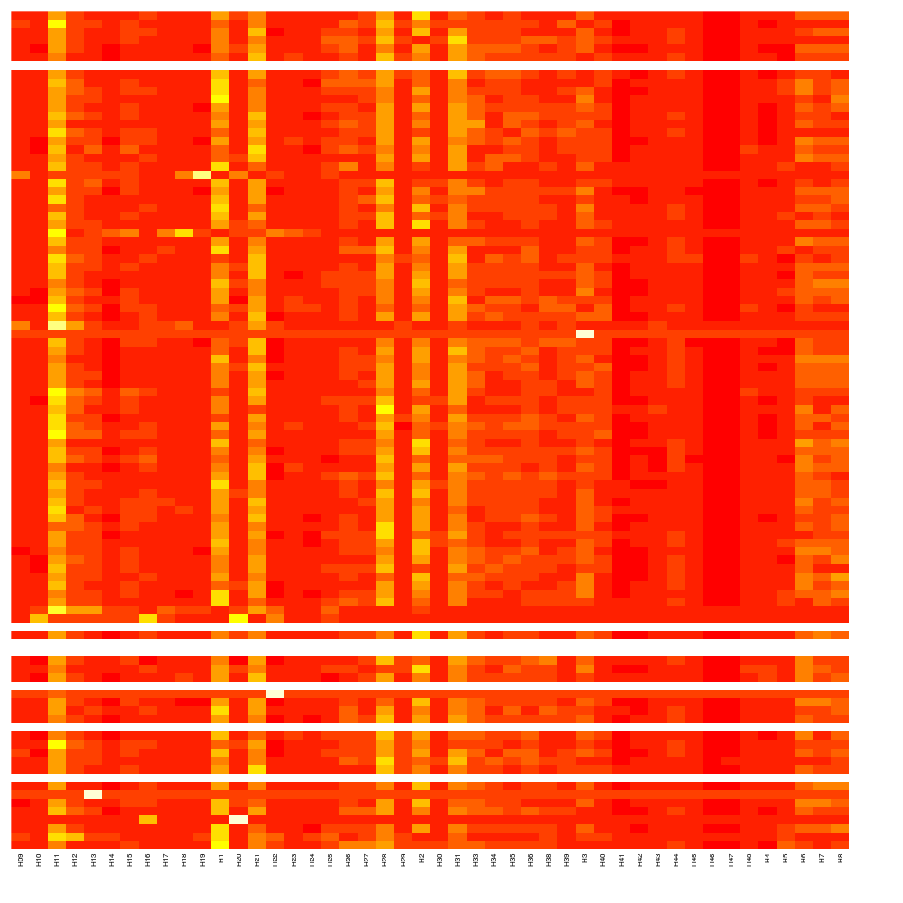

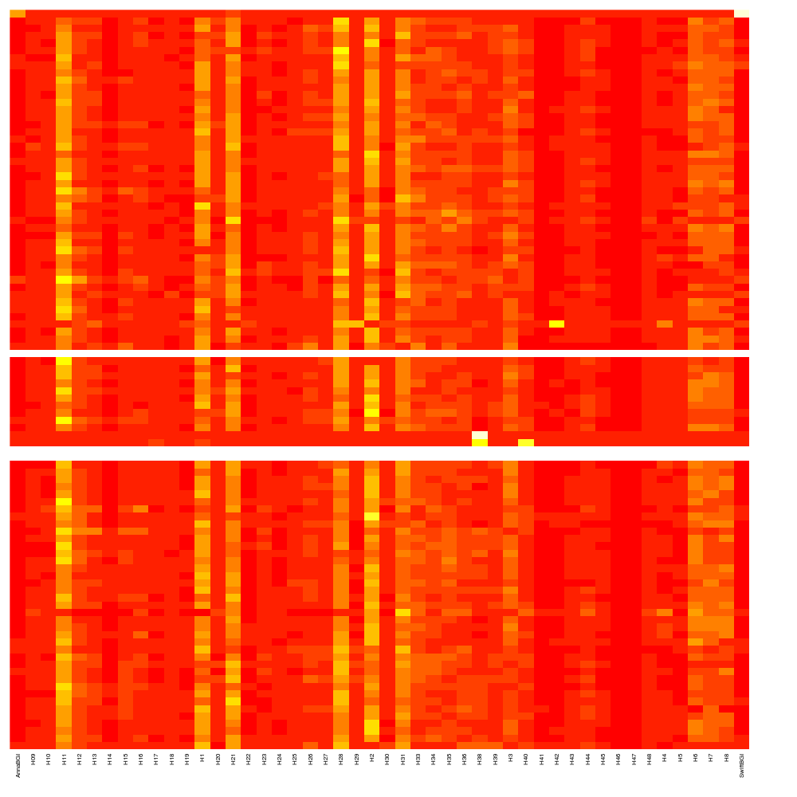

`map2Anna`

`map2Swift`

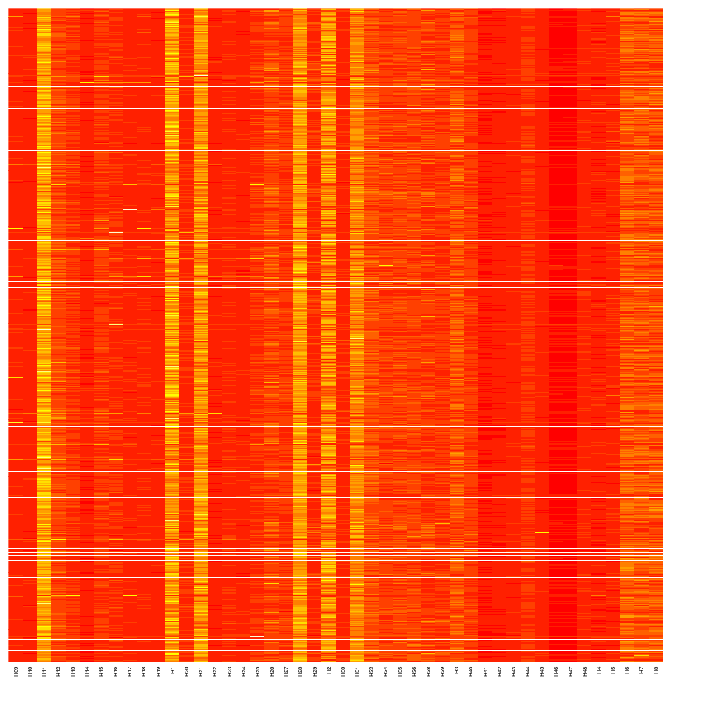

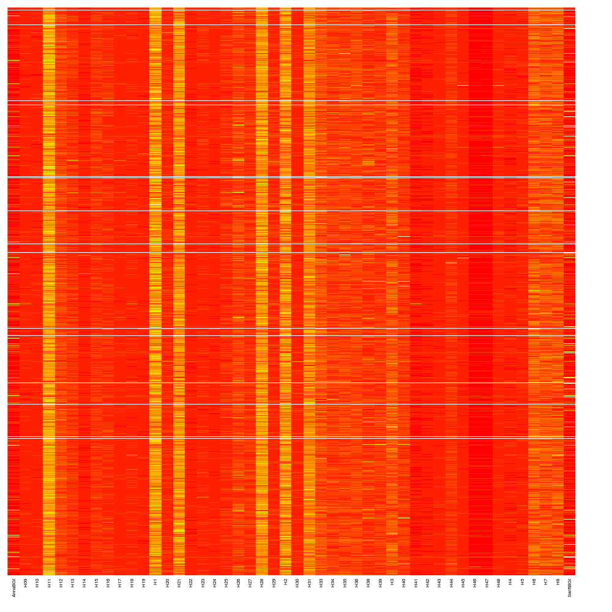

## Targeted regions not captured

Checking whether the targeted regions that were not capture are the same for all the samples. The reason why the regions matched is because the target regions file was generated a posteriori from a list of exons coming from the Chicken genome. It might be possible that:

# Off-target regions

## Generation of on and off target datasets

First, is important to define what is an off-target region. For the purpose of this analysis, there are two (`2`) definition of an off-target region. Also, I’m assuming that the all the possible DNA captured (on/off-target) is defined by a set of scaffolds in the `Calypte_anna.gene.CDS.2750.2.gff` file.

There are **580** that correspond to ~ **1,089,987,593** bp. So, taking this into account:

1. The first definition considers off-target regions as a set difference between the scaffolds and the regions in the targets file.
   1. `map2Anna`
      - off-targets $=$ *Scaffolds* $\setminus$ `Calypte_anna.gene.CDS.2750.2.gff` targets.
      - These off-targets contain **18,263** targets, corresponding to **~1,087,045,505** bp.
   2. `mapt2Swift`
      - off-targets $=$ *Scaffolds* $\setminus$ `Chaetura_pelagica.CDS.2.gff` targets.
      - These off-targets contain **14,972** targets, corresponding to **~1,087,707,387** bp.
2. The second definition considers off-target regions as a set difference between the scaffolds and the regions in `Calypte_anna.gene.CDS.2750.2.gff` and the regions in `Chaetura_pelagica.CDS.2.gff`.
   - off-targets $=$ scaffolds $\setminus$ (`Calypte_anna.gene.CDS.2750.2.gff` targets $\cup$ `Chaetura_pelagica.CDS.2.gff` targets).
   - These off-targets contain **32,606**, corresponding to **~1,084,770,828**

Generation of the off-target datasets starts with the identification of the off-target regions. First, obtaining the size of the scaffolds. This has been made by identifying the highest position per scaffold in `Calypte_anna.gene.CDS.2750.2.gff` and in `Chaetura_pelagica.CDS.2.gff`, getting with this the sizes of the scaffolds. Afterwards, generating a BED file with the regions (`scaffold, startPosition, endPosition`) and from which I subtracted both GFF target files. In this way I have the regions that were not targeted, and that are within the range of the data.

## Off-target regions across samples

The idea is to identify the off-target regions, as well as the size that covers and how is the coverage distribution within this regions compared to the on-target coverage.

To obtain coverage information from the off-target regions:

```r
for bamfile in $(find $originalsAnna -name "*.bam" ); do
  tag=$(echo $(basename $bamfile) | tr "_" " " | awk '{print $1}')
  nohup /home/merly/src/bedtools2/bin/bedtools coverage -hist -abam $bamfile -b "$HOME/files/offtarget.anna.bed" | gzip > $HOME/anna/bedtools/cov2/${tag}.cov.gz &
  nohup /home/merly/src/bedtools2/bin/bedtools coverage -hist -abam $bamfile -b "$HOME/files/offtarget.bed" | gzip > $HOME/anna/bedtools/cov3/${tag}.cov.gz &
done
for bamfile in $(find $originalsSwift -name "*.bam"  ); do
  tag=$(echo $(basename $bamfile) | tr "_" " " | awk '{print $1}')
  nohup /home/merly/src/bedtools2/bin/bedtools coverage -hist -abam $bamfile -b "$HOME/files/offtarget.swift.bed" | gzip > $HOME/swift/bedtools/cov2/${tag}.cov.gz &
  nohup /home/merly/src/bedtools2/bin/bedtools coverage -hist -abam $bamfile -b "$HOME/files/offtarget.bed" | gzip > $HOME/swift/bedtools/cov3/${tag}.cov.gz &
done
#  hist split
for tag in $(cat $HOME/anna/files/samples.txt  ); do
  zcat $HOME/anna/bedtools/cov2/$tag.cov.gz | grep -v ^all | gzip > $HOME/anna/bedtools/nohist2/$tag.nohist.gz
  zcat $HOME/anna/bedtools/cov2/$tag.cov.gz | grep ^all | gzip > $HOME/anna/bedtools/hist2/$tag.hist.gz
  zcat $HOME/anna/bedtools/cov3/$tag.cov.gz | grep -v ^all | gzip > $HOME/anna/bedtools/nohist3/$tag.nohist.gz
  zcat $HOME/anna/bedtools/cov3/$tag.cov.gz | grep ^all | gzip > $HOME/anna/bedtools/hist3/$tag.hist.gz
done
for tag in $(cat $HOME/swift/files/samples.txt  ); do
  zcat $HOME/swift/bedtools/cov2/$tag.cov.gz | grep -v ^all | gzip > $HOME/swift/bedtools/nohist2/$tag.nohist.gz
  zcat $HOME/swift/bedtools/cov2/$tag.cov.gz | grep ^all | gzip > $HOME/swift/bedtools/hist2/$tag.hist.gz
  zcat $HOME/swift/bedtools/cov3/$tag.cov.gz | grep ^all | gzip > $HOME/swift/bedtools/hist3/$tag.hist.gz
  zcat $HOME/swift/bedtools/cov3/$tag.cov.gz | grep -v ^all | gzip > $HOME/swift/bedtools/nohist3/$tag.nohist.gz
done
```

## Breadth vs. depth of coverage

I followed what has been done for the on-target regions to get this information. Getting how much of the off-target regions was captured, and at which depth.

`map2Anna`

`map2Swift`

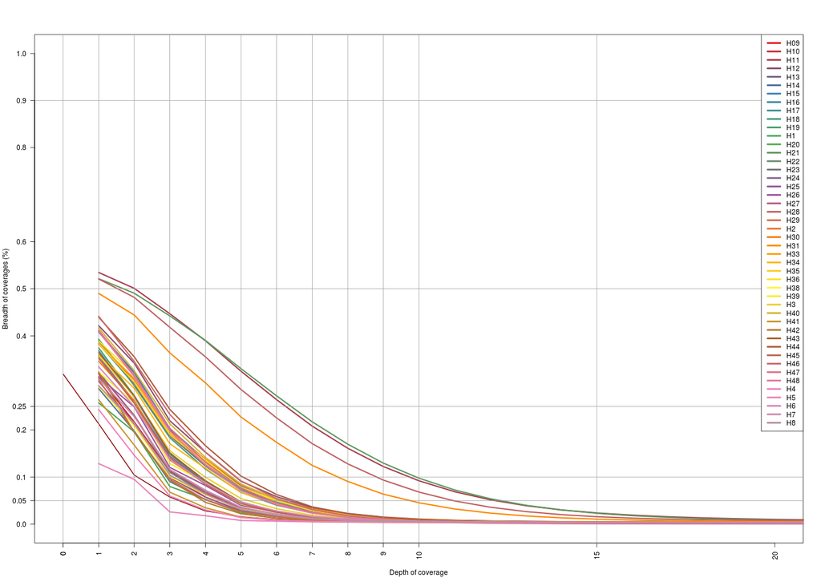

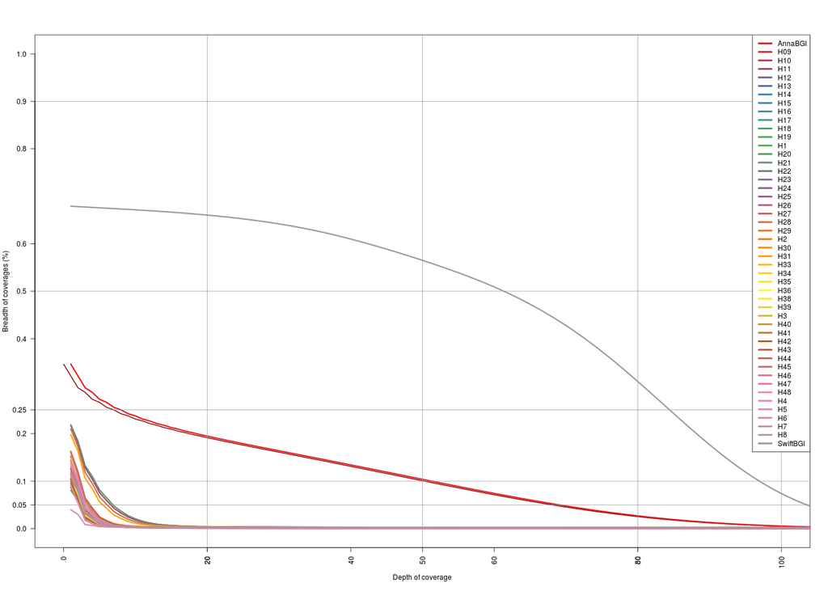

X-axis: 0-20

X-axis: 0-100

## ANGSD Depth calculations

This computes depth distribution for every sample and for all samples jointly. Computed wiht ANGSD [angsd version: 0.916 (htslib: 1.3.2) build(May 2 2017 16:21:49)].

```
angsd -bam bam.filelist -doDepth 1 -out all -doCounts 1 -maxDepth 1000
```

Output of ANGSD are 2 files:

- `.depthSample`: This file contains nInd number of lines. Column1 is the number sites that has sequencing depth=0,Column2 is the number of sites that has sequencing depth=1 etc
- `.depthGlobal`: The sequencing depth for all samples.

# Relation within coverage and phylogenetic distance

I am trying to analyze if there is any correlation between the depth of coverage and the phylogenetic distance from the reference species, used for the probe generation and mapping.

## Inferred phylogeny from Hummingbirds

Information of the phylogenetic reconstruction I got from the Hummingbirds Paper, this says that it was made with mitochondrial genome and nuclear gene trees using either a concatenation approach with RAxML [3] or the multi-species coalescent approach implemented in ASTRAL [4] and ASTRAL-II [5].

The phylogenies were built using subsets of the nuclear genes present the same topology between the main groups of hummingbirds with high confidence. The three subsets correspond to:

This is the Supplementary Table S5 (from the Hummingbirds Paper), describing the subsets selected:

| number of genes | minimum number of sites per species (concatenated) | maximum number of sites per species (concatenated) | includes outgroup | ASTRAL score |
| --- | --- | --- | --- | --- |
| 741 | 949,470 | 1,542,750 | yes | 87% |
| 1987 | 1,667,071 | 2,783,832 | yes | 78% |
| 2949 | 2,473,664 | 3,792,500 |  |  |

Is this really this dataset? weren’t we working with originally 2750 genes?

I’ll be using only the subset for the 2949 genes.

- `Cpe`, outgroup reference.
- `Aan`, ingroup reference.

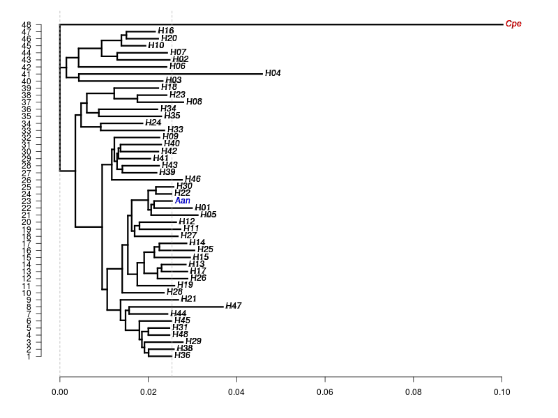

Inferred phylogeny

## Distance Matrix from inferred phylogeny

To obtain the distance matrix I used the tree obtained with RAxML, from the concatenation of 2949 genes. The tree gives me the branch lengths in number of substitutions per site. So, the distance calculated here, is the pairwise distance of the tips. This was done with the R package `phangorn` [7]

```r
sampleColors = colorRampPalette(brewer.pal(9, "Set1"))(48)
treefile="/home/merly/git/cph-visit/coverage-analysis/capture-phylotenetic-decay/trees/RAxML_bipartitions.2011.concat"
tree=read.nexus(treefile)
distMatrix=cophenetic(tree)
dCpe=distMatrix["Cpe",]
dAan=distMatrix["Aan",]
distMatrix[upper.tri(distMatrix)]=NA
```

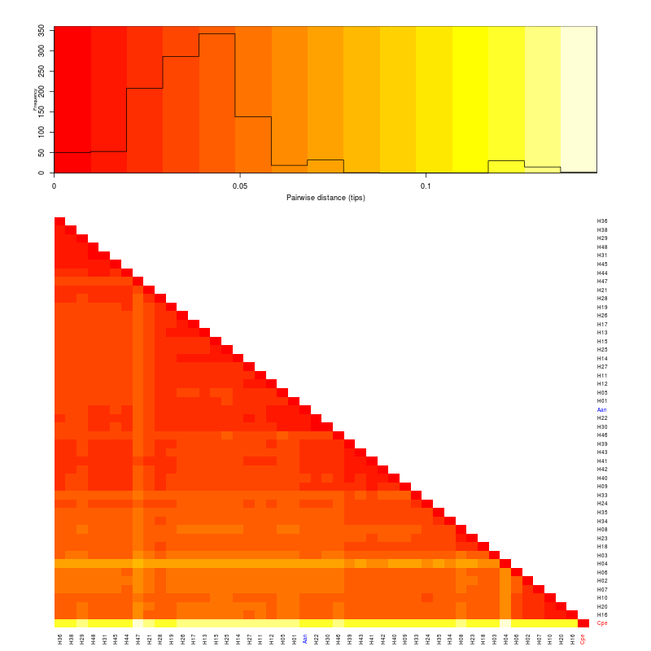

Distance matrix

## Correlations

### Anna

interpret this

### Swift

interpret this

**References**

- [1]: Bleiweiss R, Kirsch JAW, Matheus JC (1994) *DNA-DNA Hybridization Evidence for Sub-family Structure among Hummingbirds*. Auk 111(1):8–19. [DOI: 10.2307/4088500](http://www.jstor.org/stable/4088500)
- [2]: McGuire JA, et al. (2014) *Molecular phylogenetics and the diversification of hummingbirds*. Curr Biol 24(8):910–6. [DOI: 10.1016/j.cub.2014.03.016](http://www.sciencedirect.com/science/article/pii/S0960982214002759)
- [3]: Stamatakis A (2014) *RAxML version 8: a tool for phylogenetic analysis and post-analysis of large phylogenies.* Bioinformatics 30(9):1312–1313. [DOI: 10.1093/bioinformatics/btu033](https://doi.org/10.1093/bioinformatics/btu033)
- [4]: Mirarab S, et al. (2014) *ASTRAL: genome-scale coalescent-based species tree estimation.* Bioinformatics 30(17):i541–8. [DOI: 10.1093/bioinformatics/btu462](https://doi.org/10.1093/bioinformatics/btu462)
- [5]: Mirarab S, Warnow T (2015) *ASTRAL-II: coalescent-based species tree estimation with many hundreds of taxa and thousands of genes.* Bioinformatics 31(12):i44–52. [DOI: 10.1093/bioinformatics/btv234](https://doi.org/10.1093/bioinformatics/btv234)
- [6]: Jarvis ED, et al. (2014) *Whole Genome Analyses Resolve the Early Branches in the Tree of Life of Modern Birds.* Science (80- ) 346(6215):1320–1331. [DOI: 10.1126/science.1253451](http://science.sciencemag.org/content/346/6215/1320)
- [7]: Klaus Peter Schliep (2011) *phangorn: phylogenetic analysis in R.* Bioinformatics 27 (4): 592-593. [DOI: 10.1093/bioinformatics/btq706](https://doi.org/10.1093/bioinformatics/btq706)
- [8]: Bragg, JG., Potter, S., Bi. K. and Moritz, C. (2016) *Exon capture phylogenomics: efficacy across scales of divergence* Molecular Ecology Resources 16, 1059–1068. [DOI: 10.1111/1755-0998.12449](http://onlinelibrary.wiley.com/doi/10.1111/1755-0998.12449/pdf)